# K-Folds CrossValidation

The purpose of this notebook is to perform a k-folds crossvalidation of the lmer model. I’m following along with an example from [here](https://rpubs.com/ledongnhatnam/241926)

**Import libraries and data:**

```r
library(tidyverse)
library(lme4)
library(parallel)
library(data.table)
current_data <- fread('../data/exp1_clean.csv')
```

First order of business is to build a generalized, custom function of the function cvTools::cvFolds

```r
## cvFolds(n `number of observations to be split into groups`, K = 5 `number of groups into which observations should be split`, R = 1 `number of replications`)

fold_cv <- function(data, k) {
  folds <- cvTools::cvFolds(nrow(data), K = k)
  invisible(folds)
}
```

Then apply to the data.  
*I’m actually unsure how this implementation is different from just using `cvFolds` straight up, so I’ll test that out.*

```r
fold <- current_data %>% fold_cv(., k = 10)
fold1 <- cvTools::cvFolds(nrow(current_data), K = 10)

str(fold)
```

```
## List of 5
##  $ n      : num 6271
##  $ K      : num 10
##  $ R      : num 1
##  $ subsets: int [1:6271, 1] 3479 4678 5188 5901 3051 2136 5260 1461 3657 5495 ...
##  $ which  : int [1:6271] 1 2 3 4 5 6 7 8 9 10 ...
##  - attr(*, "class")= chr "cvFolds"
```

```r
str(fold1)
```

```
## List of 5
##  $ n      : num 6271
##  $ K      : num 10
##  $ R      : num 1
##  $ subsets: int [1:6271, 1] 4449 4511 4485 2585 562 1223 5393 3471 2096 2160 ...
##  $ which  : int [1:6271] 1 2 3 4 5 6 7 8 9 10 ...
##  - attr(*, "class")= chr "cvFolds"
```

The next step is to add on to the current data set empty columns for the values we’ll be deriving from running the model on each fold we’ve made in the data.

```r
temp <- current_data %>% mutate(fold_id = rep(0, nrow(.)),
                                holdoutpred = rep(0, nrow(.)),
                                mse = rep(0, nrow(.)),
                                rmse = rep(0, nrow(.)),
                                mae = rep(0, nrow(.)),
                                r2 = rep(0, nrow(.)),
                                AIC = rep(0, nrow(.)),
                                BIC = rep(0, nrow(.)))
```

Now I’ll run the model we settled on in the “Inferential” notebook, run it on each fold and evaluate performance.

```r
for (i in 1:10){
  ## use the fold data to break current data into train and test
  train <- temp[fold$subsets[fold$which != i],]
  validation <- temp[fold$subsets[fold$which == i],]
  ## run the model on the training data
  m1 <- lmer(rt ~ cycle * item_type * context * block +
             (1 | subject) +
             (1 | subject:cycle) +
             (1 | subject:block) +
             (1 | item:item_type) +
             (1 | item:context),
           data = train, control = lmerControl(optimizer = 'Nelder_Mead', optCtrl = list(maxfun = 100000)))
  proba <- predict(m1, newdata = validation)
  true <- validation$rt
  error <- true - proba
  rmse <- sqrt(mean(error^2))
  mse <- rmse^2
  r2 <- 1 - (sum((true-proba)^2)) / (sum((true - mean(true))^2))
  mae <- mean(abs(error))
  temp[fold$subsets[fold$which == i], ]$fold_id <- i
  temp[fold$subsets[fold$which == i], ]$holdoutpred <- proba
  temp[fold$subsets[fold$which == i], ]$mse <- mse
  temp[fold$subsets[fold$which == i], ]$rmse <- rmse
  temp[fold$subsets[fold$which == i], ]$mae <- mae
  temp[fold$subsets[fold$which == i], ]$r2 <- r2
  temp[fold$subsets[fold$which == i], ]$AIC <- AIC(m1)
  temp[fold$subsets[fold$which == i], ]$BIC <- BIC(m1)
}
```

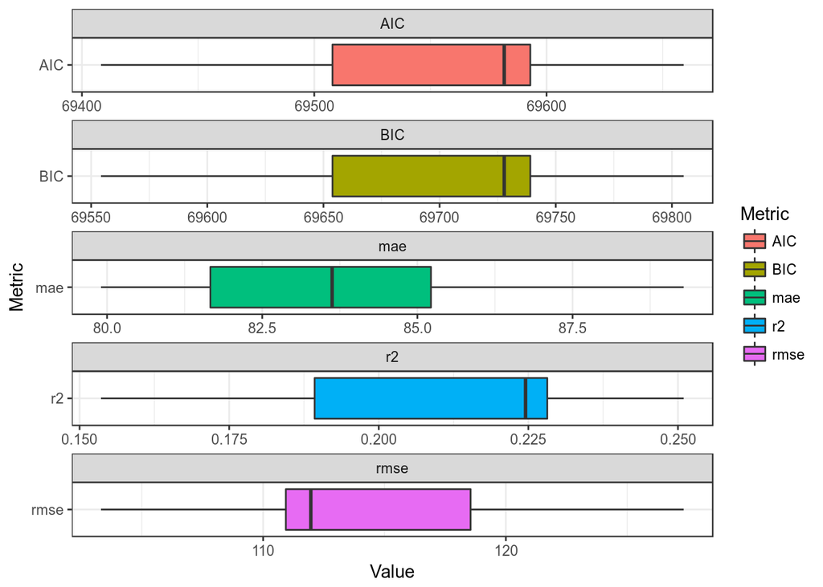

```r
temp %>%
  gather(rmse:BIC, key = 'Metric', value = 'Value') %>%
  ggplot(aes(x = Metric, y = Value, fill = Metric)) + geom_boxplot() + coord_flip() + facet_wrap(~Metric, ncol = 1, scales = 'free') + theme_bw()
```

```r
temp <- current_data %>% mutate(fold_id = rep(0, nrow(.)),
                                holdoutpred = rep(0, nrow(.)),
                                mse = rep(0, nrow(.)),
                                rmse = rep(0, nrow(.)),
                                mae = rep(0, nrow(.)),
                                r2 = rep(0, nrow(.)),
                                AIC = rep(0, nrow(.)),
                                BIC = rep(0, nrow(.)))
```

```r
for (i in 1:10){
  ## use the fold data to break current data into train and test
  train <- temp[fold$subsets[fold$which != i],]
  validation <- temp[fold$subsets[fold$which == i],]
  ## run the model on the training data
  m2 <- lm(rt ~ cycle * item_type * context * block, data = train)
  proba <- predict(m1, newdata = validation)
  true <- validation$rt
  error <- true - proba
  rmse <- sqrt(mean(error^2))
  mse <- rmse^2
  r2 <- 1 - (sum((true-proba)^2)) / (sum((true - mean(true))^2))
  mae <- mean(abs(error))
  temp[fold$subsets[fold$which == i], ]$fold_id <- i
  temp[fold$subsets[fold$which == i], ]$holdoutpred <- proba
  temp[fold$subsets[fold$which == i], ]$mse <- mse
  temp[fold$subsets[fold$which == i], ]$rmse <- rmse
  temp[fold$subsets[fold$which == i], ]$mae <- mae
  temp[fold$subsets[fold$which == i], ]$r2 <- r2
  temp[fold$subsets[fold$which == i], ]$AIC <- AIC(m1)
  temp[fold$subsets[fold$which == i], ]$BIC <- BIC(m1)
}
```

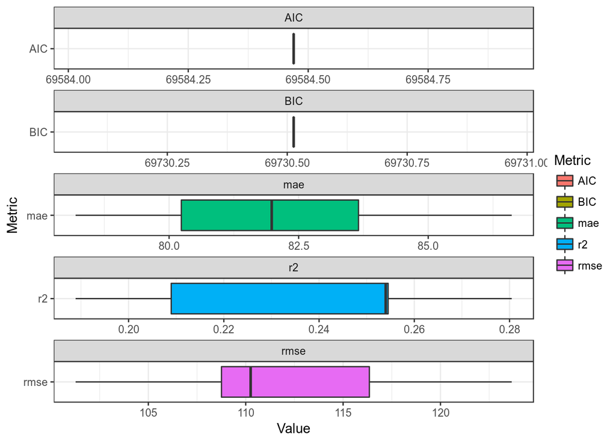

```r
temp %>%
  gather(rmse:BIC, key = 'Metric', value = 'Value') %>%
  ggplot(aes(x = Metric, y = Value, fill = Metric)) + geom_boxplot() + coord_flip() + facet_wrap(~Metric, ncol = 1, scales = 'free') + theme_bw()
```